# PSDV Prerequisite Beli Dedhia

## PSDV PREREQUISITE ASSIGNMENT - BELI DEDHIA

### 1. List Operations and Basic Statistics

- Create a list of the first 20 natural numbers.
- Compute the sum of all even numbers in the list.
- Compute the product of all odd numbers in the list.
- Calculate the mean, median, and standard deviation of the list.

```python
l=list(range(1,21))
s=0
p=1
for i in l:
    if i%2==0:
        s=s+i
    else:
        p=p*i

meanl=sum(l)/len(l)

def medianl(l):
    l.sort()
    k=len(l)
    if len(l)%2==0:
        m=l[(k//2)]+l[(k//2)+1]
    else:
        m=l[(k+1)//2]
    return m

for i in l:
    sv=0
    d=(i-meanl)**2
    sv=sv+d
    sd=(sv/len(l))**0.5

print(l)
print(s)
print(p)
print(meanl, medianl(l), sd)
```

```
[1, 2, 3, 4, 5, 6, 7, 8, 9, 10, 11, 12, 13, 14, 15, 16, 17, 18, 19, 20]
110
654729075
10.5 23 2.1242645786248002
```

### 2. Mutable vs. Immutable Data Types:

- Explain the difference between mutable and immutable data types in Python. Provide examples of each.

The object that can't be modified is called immutable examples are tuple,string while the once which can be modified is called mutable example list, dictionary.

### 3. Fibonacci Sequence:

- Write a Python function that takes a number n and returns a list of the first n Fibonacci numbers.
- Plot the Fibonacci sequence using a line graph.

```
[0, 1, 1, 2, 3, 5, 8, 13]
```

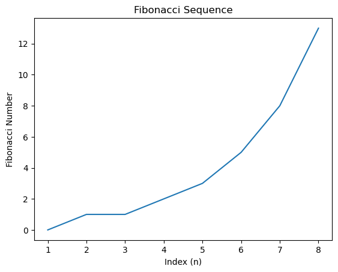

```python
import matplotlib.pyplot as plt
n=int(input())
def fibo(n):
    l = [0, 1]

    for i in range(2, n):
        k = l[-1] + l[-2]
        l.append(k)

    return l

print(fibo(n))
f = fibo(n)
plt.plot(range(1, n + 1), f)
plt.title('Fibonacci Sequence')
plt.xlabel('Index (n)')
plt.ylabel('Fibonacci Number')
plt.show()
```

### 4. List Manipulation:

- Given a list [3, 5, 7, 9, 11, 13]:
- Insert 6 at the 3rd index.
- Remove the number 7 from the list.
- Reverse the list.
- Calculate the mean and median of the modified list.

```python
l= [3, 5, 7, 9, 11, 13]
l.insert(3,6)
l.pop(2)
l=l[::-1]
import statistics as s
mean1 =s.mean(l)
median1 =s.median(l)
print(l)
print(mean1, median1)
```

```
[13, 11, 9, 6, 5, 3]
7.833333333333333 7.5
```

### 5. User Input and Basic Statistics:

- Write a program to read a comma-separated list of numbers from the user (e.g., “10, 20, 30, 40”).
- Calculate the mean of the numbers.
- Identify and print the smallest and largest numbers.
- Plot a histogram of the numbers.

```
25.0
40
10
```

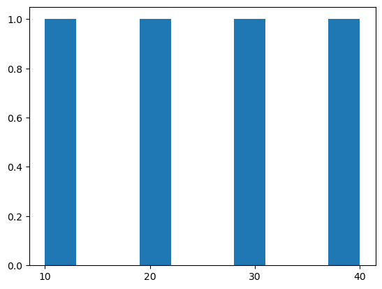

```python
s="10,20,30,40"
l=s.split(',')
s=0
for i in l:
    s=s+int(i)

mean= s/4
print(mean)
maxlist=max(l)
minlist=min(l)
print(maxlist)
print(minlist)

import matplotlib.pyplot as plt
plt.hist(l)
plt.show()
```

### 6. Palindrome Check:

- Write a program to check if a string is a palindrome (ignoring spaces and case).
- Input: "A man a plan a canal Panama"
- Output: True

```python
s = input()
s = s.replace(' ','')
s = s.lower()
sr = s[::-1]
if s == sr:
    print(True)
else:
    print(False)
```

```
True
```

### 7. Dictionary Operations:

- Create a dictionary of student names (keys) and their marks (values).
- Compute the average marks.
- Print the names of students scoring above the average.
- Visualize the distribution of marks using a bar chart.

```
Ross
Monica
Chandler
Joey
```

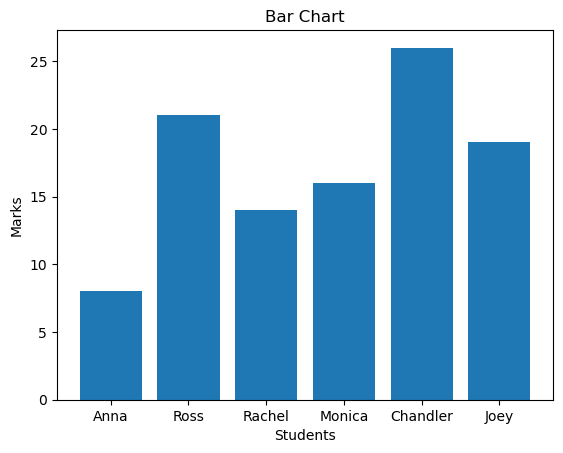

```python
ds={"Anna":8, "Ross":21, "Rachel":14, "Monica":16, "Chandler": 26, "Joey":19}
s=0
c=1
for k,v in ds.items():
    s+=v
    c+=1

mean=s/c
for k,v in ds.items():
    if mean<v:
        print(k)
import matplotlib.pyplot as plt

plt.bar(ds.keys(),ds.values())
plt.title("Bar Chart")
plt.xlabel("Students")
plt.ylabel("Marks")
plt.show()
```

### 8. Tuple List Creation:

- Create a list of tuples, where each tuple contains a number and its square (e.g., [(1, 1), (2, 4), (3, 9), ...] for numbers 1 to 10).
- Plot the numbers and their squares on a scatter plot.

```
[(1, 1), (2, 4), (3, 9), (4, 16), (5, 25), (6, 36), (7, 49), (8, 64), (9, 81), (10, 100)]
```

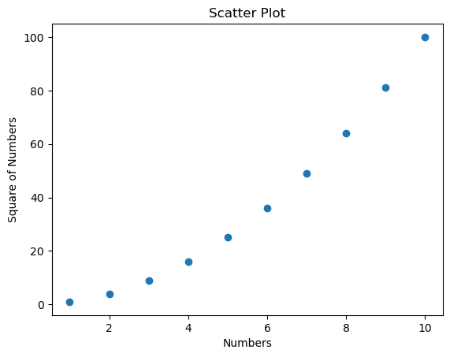

```python
import matplotlib.pyplot as plt
sq=[(n,n ** 2) for n in range(1,11)]
print(sq)

x = range(1, 11)
y = [n**2 for n in x]
plt.scatter(x,y)
plt.title("Scatter Plot")
plt.xlabel("Numbers")
plt.ylabel("Square of Numbers")
plt.show()
```

### 9. Merging Dictionaries:

- Write Python code to merge two dictionaries. If a key is present in both, sum their values.

```python
dict1 = {'a': 10, 'b': 20}
dict2 = {'b': 5, 'c': 15}
finald=dict1
for k in dict2:
    if k in finald:
        finald[k]+=dict2[k]
    else:
        finald[k]= dict2[k]
print(finald)
```

```
{'a': 10, 'b': 25, 'c': 15}
```

### 10. Character Frequency:

- Write a function that accepts a string and:
- Converts all characters to lowercase.
- Counts the frequency of each character.
- Returns a dictionary with characters as keys and their counts as values.
- Visualize the character frequencies using a bar chart.

```
{'m': 2, 'y': 1, 'n': 1, 'a': 2, 'e': 3, 'i': 3, 's': 1, 'b': 1, 'l': 1, 'd': 2, 'h': 1}
```

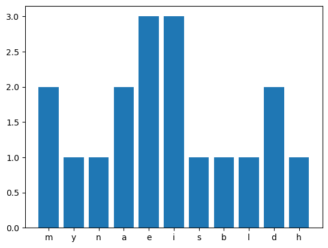

```python
import matplotlib.pyplot as plt
inputStr = input().replace(' ','')
inputStr = inputStr.lower()
dict1 = {}
for i in inputStr:
    if i in dict1:
        dict1[i] += 1
    else:
        dict1[i] = 1
print(dict1)
x = list(dict1.keys())
y = list(dict1.values())
plt.bar(x, y)
plt.show()
```

### 11. Remove Duplicates:

- Write a program to remove duplicate elements from a list while maintaining the order of elements.
- Calculate the mean and median of the unique elements.

```python
l=[1,2,3,4,5,6,3,3,6,2,8,7,7,9]
c=0
d={}
for i in l:
    if i in d:
        d[i]=d[i]+1

    else:
        d[i]=1
finall=list(d.keys())
mean=sum(finall)/len(finall)
print(mean, medianl(finall))
```

```
5.0 6
```

### 12. String Operations:

- Given a list of strings, write a Python function to:
- Find the longest string.
- Count how many strings start with a vowel.
- Visualize the distribution of string lengths using a histogram.

```
(10, 1)
```

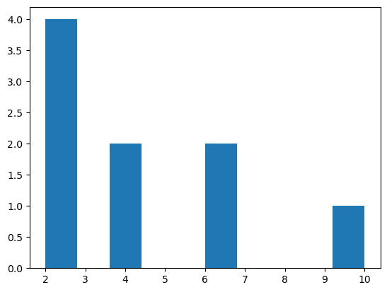

```python
def strfunc(l):
    length=0
    count=0
    for string in l:
        if len(string)>length:
            maxl=len(string)
    if string[0].upper() in 'AEIOU':
        count+=1
    return maxl,count
l=['my','name','is','beli','dedhia','my','branch','is','Electrical']
s=strfunc(l)
print(s)
import matplotlib.pyplot as plt
x=l
y=[len(s) for s in l]
plt.hist(y)
plt.show()
```

### 13. Sorting Dictionaries:

- Write a function to sort a list of dictionaries by a key.
- Example:
- data = [{'name': 'Alice', 'age': 25}, {'name': 'Bob', 'age': 22}] Sort by age → [{'name': 'Bob', 'age': 22}, {'name': 'Alice', 'age': 25}]

```python
data = [{'name': 'Alice', 'age': 25}, {'name': 'Bob', 'age': 22}]
for i in range(len(data)-1):
    if data[i]['age']>data[i+1]['age']:
        t=data[i]
        data[i]=data[i+1]
        data[i+1]=t
    else:
        continue

print(data)
```

```
[{'name': 'Bob', 'age': 22}, {'name': 'Alice', 'age': 25}]
```

### 14. Word Filtering and Sorting:

- Write a program to:
- Split a string into a list of words.
- Remove all words that are shorter than 4 characters.
- Sort the remaining words alphabetically.
- Visualize the word lengths using a bar chart.

```
['Sort', 'remaining', 'words', 'alphabetically.', 'Visualize', 'word', 'lengths', 'using', 'bar', 'chart.']
None
```

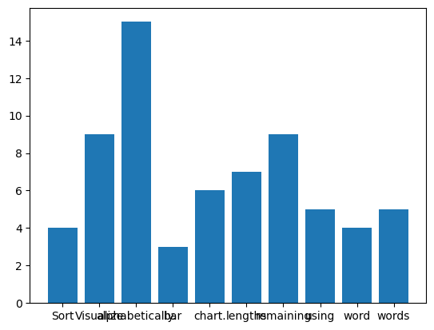

```python
s=input().strip()
word=s.split()
for i in word:
    if len(i)<4:
        word.remove(i)
print(word)
print(word.sort())

import matplotlib.pyplot as plt
plt.bar(word,[len(i) for i in word])
plt.show()
```

### 15. Anagram Finder:

- Write a Python function to find all anagrams of a word in a given list.
- Input: word = "listen", words = ["enlist", "google", "inlets", "banana"]
- Output: ["enlist", "inlets"]

```python
word="listen"
words = ["enlist", "google", "inlets", "banana"]
l=[]
sword=sorted(word)
for i in words:
    if sorted(i) == sword:
        l.append(i)

print(l)
```

```
['enlist', 'inlets']
```

### 16.Set Operations:

Given two lists, write Python code to find their intersection, union, and symmetric difference. Visualize the results using Venn diagrams.

```
{1, 2, 3, 4, 5, 6, 7, 8, 10}
{2, 4, 6}
{1, 3, 5, 7, 8, 10}
```

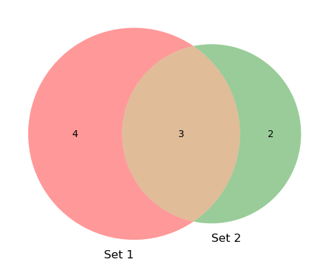

```python
import matplotlib.pyplot as plt
from matplotlib_venn import venn2
set1 = {1,2,3,4,5,6,7}
set2={2,4,6,8,10}
print(set1|set2)
print(set1&set2)
print(set1^set2)
set1 = set(set1)
set2 = set(set2)
venn2([set1, set2], ('Set 1', 'Set 2'))
plt.show()
```

### 17. File Operations:

- Write Python code to:
- Create a text file.
- Write a list of numbers to the file (one per line).
- Read the file and compute their sum.

```python
file = open("data.txt", "w+")
for i in range(15):
    file.write(f'{i}\n')
file.close()


file = open('data.txt','r')
content = file.read()
n = content.split('\n')
sumn = 0
for i in n:
    if len(i) != 0:
        sumn += int(i)
print(sumn)
```

```
105
```

### 18. Word Count and Frequency:

- Write a program to:
- Read a file and count the number of words in it.
- Find the most frequent word.
- Visualize the word frequencies using a bar chart.

```
a
```

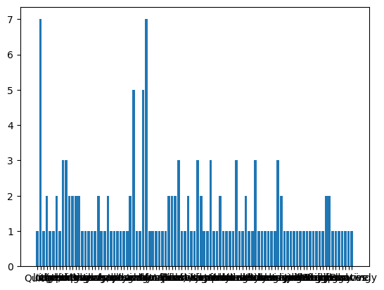

```python
import matplotlib.pyplot as plt
f = open("words.txt")
counts = dict()
for line in f:
    words = line.split()
    for word in words:
        counts[word] = counts.get(word,0) + 1
maxcount = None
maxword = None
for k,v in counts.items():
    if maxcount is None or v > maxcount:
        maxword = k
        maxcount = v

print(maxword)

plt.bar(counts.keys(), counts.values())
plt.show()
```

### 19. Random Number Generation:

```
51.14
```

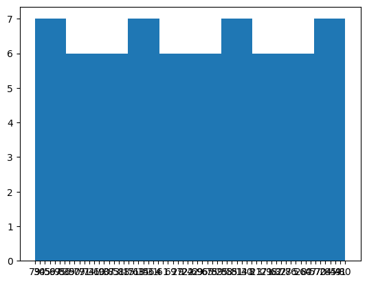

```python
import random
import matplotlib.pyplot as plt
rn = []
for i in range(100):
    rn.append(random.randint(1,100))
file = open('rns.txt','w+')
for n in rn:
    file.write(f'{n}\n')
file.close()
file = open('rns.txt','r')
c = file.read()
ns = c.split('\n')
s = 0
d = {}
for n in ns:
    if len(n) != 0:
        s = s + int(n)
        if n in d:
            d[n] += 1
        else:
            d[n] = 1
print(s/len(rn))
plt.hist(list(d.keys()),bins=10)
plt.show()
```

### 20, CSV File Operations:

Write Python code to read a CSV file and compute the sum of values in a specific column. Visualize the data using a line plot.

```
20
```

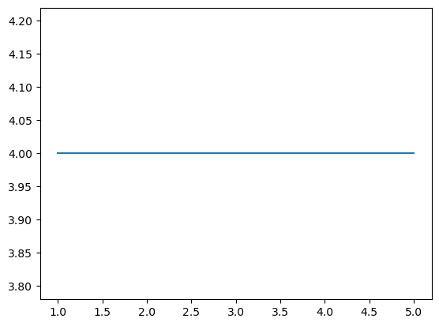

```python
import csv
import matplotlib.pyplot as plt
data = list(csv.reader(open('data.csv')))
c= int(input())
sumn = 0
requiredRow = []

for row in data:
    element = int(row[c])
    sumn += element
    requiredRow.append(element)

n = len(requiredRow)
print(sumn)
plt.plot(range(1, n + 1), requiredRow)
plt.show()
```

### 21. Basic Statistics:

```python
import matplotlib.pyplot as plt
import math
import random
l = []
for i in range(100):
    l.append(random.randint(1,100))
mean = sum(l) / len(l)
l.sort()
median = 0
if len(l) % 2 == 0:
    median1 = l[len(l)//2]
    median2 = l[len(l)//2 - 1]
    median = (median1 + median2)/2
else:
    median = l[len(l)//2]

f= {}
for num in l:
    if num in f:
        f[num] += 1
    else:
        f[num] = 1
mode = [num for num,freq in f.items() if freq == max(f.values())]
sd = math.sqrt(sum(pow(num-mean,2) for num in l)/len(l))
print(mean, median, mode, sd)
```

```
50.2 55.0 [56, 88] 29.526936854336924
```

### 22. Normalization:

- Write a Python function to normalize a list of numbers to a range of 0 to 1.
- Visualize the normalized data using a line plot.

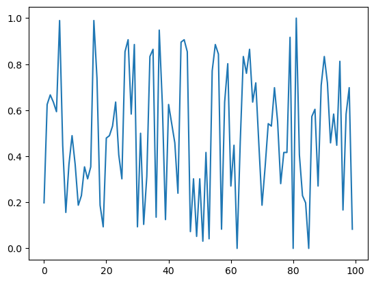

```python
import matplotlib.pyplot as plt
import random
l = []
for i in range(100):
    l.append(random.randint(1,100))
nl = []
for num in l:
    nl.append((num-min(l))/(max(l)-min(l)))
plt.plot(nl)
plt.show()
```

### 23. Even or Odd:

Write a Python program that takes an integer input from the user and prints whether the number is even or odd.

```python
n = int(input())
if n%2==0:
    print('even number')
else:
    print(' odd number')
```

```
 odd number
```

### 24. Grade Calculator:

- Write a Python program that takes a numerical grade (0-100) as input and prints the corresponding letter grade (A, B, C, D, F).

```python
marks = int(input())
if 80<=marks<=100:
    print("A Grade")
elif 60<=marks<=79:
    print("B Grade")
elif 40<=marks<=59:
    print("C Grade")
elif 20<=marks<=39:
    print("D Grade")
elif 0<=marks<=19:
    print("F Grade")
else:
    print("Invalid Range")
```

```
B Grade
```

### 25. Leap Year Checker:

Write a Python program that takes a year as input and checks if it is a leap year.

```python
year = int(input())
if year % 4 == 0:
    if year % 100 != 0:
        print("leap year")
    else:
        print(" Not a leap year")
elif year % 400 == 0:
    print("leap year")
else:
    print("Not a leap year")
```

```
 Not a leap year
```